# Risk Factor Analysis

## Outcome Variable

**Outcome Variable:** sstunted

## Predictor Variables

**Intervention Variable:** mwtkg

**Adjustment Set:**

unadjusted

## Stratifying Variables

The analysis was stratified on these variable(s):

- agecat
- studyid
- country

## Data Summary

| agecat | studyid | country | A | n | nA | nAY0 | nAY1 |
| --- | --- | --- | --- | --- | --- | --- | --- |
| Birth | ki0047075b-MAL-ED | BANGLADESH | >=57.5 | 246 | 50 | 50 | 0 |
| Birth | ki0047075b-MAL-ED | BANGLADESH | <42.5 | 246 | 53 | 50 | 3 |
| Birth | ki0047075b-MAL-ED | BANGLADESH | [42.5-50) | 246 | 85 | 82 | 3 |
| Birth | ki0047075b-MAL-ED | BANGLADESH | [50-57.5) | 246 | 58 | 57 | 1 |
| Birth | ki0047075b-MAL-ED | BRAZIL | >=57.5 | 184 | 122 | 116 | 6 |
| Birth | ki0047075b-MAL-ED | BRAZIL | <42.5 | 184 | 12 | 12 | 0 |
| Birth | ki0047075b-MAL-ED | BRAZIL | [42.5-50) | 184 | 13 | 13 | 0 |
| Birth | ki0047075b-MAL-ED | BRAZIL | [50-57.5) | 184 | 37 | 35 | 2 |
| Birth | ki0047075b-MAL-ED | INDIA | >=57.5 | 198 | 37 | 37 | 0 |
| Birth | ki0047075b-MAL-ED | INDIA | <42.5 | 198 | 34 | 32 | 2 |
| Birth | ki0047075b-MAL-ED | INDIA | [42.5-50) | 198 | 67 | 65 | 2 |
| Birth | ki0047075b-MAL-ED | INDIA | [50-57.5) | 198 | 60 | 57 | 3 |
| Birth | ki0047075b-MAL-ED | NEPAL | >=57.5 | 172 | 63 | 62 | 1 |
| Birth | ki0047075b-MAL-ED | NEPAL | <42.5 | 172 | 2 | 2 | 0 |
| Birth | ki0047075b-MAL-ED | NEPAL | [42.5-50) | 172 | 30 | 27 | 3 |
| Birth | ki0047075b-MAL-ED | NEPAL | [50-57.5) | 172 | 77 | 75 | 2 |
| Birth | ki0047075b-MAL-ED | PERU | >=57.5 | 276 | 99 | 96 | 3 |
| Birth | ki0047075b-MAL-ED | PERU | <42.5 | 276 | 13 | 11 | 2 |
| Birth | ki0047075b-MAL-ED | PERU | [42.5-50) | 276 | 52 | 51 | 1 |
| Birth | ki0047075b-MAL-ED | PERU | [50-57.5) | 276 | 112 | 111 | 1 |
| Birth | ki0047075b-MAL-ED | SOUTH AFRICA | >=57.5 | 228 | 166 | 166 | 0 |
| Birth | ki0047075b-MAL-ED | SOUTH AFRICA | <42.5 | 228 | 2 | 2 | 0 |
| Birth | ki0047075b-MAL-ED | SOUTH AFRICA | [42.5-50) | 228 | 13 | 13 | 0 |
| Birth | ki0047075b-MAL-ED | SOUTH AFRICA | [50-57.5) | 228 | 47 | 46 | 1 |
| Birth | ki0047075b-MAL-ED | TANZANIA, UNITED REPUBLIC OF | >=57.5 | 121 | 56 | 55 | 1 |
| Birth | ki0047075b-MAL-ED | TANZANIA, UNITED REPUBLIC OF | <42.5 | 121 | 4 | 3 | 1 |
| Birth | ki0047075b-MAL-ED | TANZANIA, UNITED REPUBLIC OF | [42.5-50) | 121 | 28 | 26 | 2 |
| Birth | ki0047075b-MAL-ED | TANZANIA, UNITED REPUBLIC OF | [50-57.5) | 121 | 33 | 31 | 2 |
| Birth | ki1000304b-SAS-CompFeed | INDIA | >=57.5 | 69 | 3 | 3 | 0 |
| Birth | ki1000304b-SAS-CompFeed | INDIA | <42.5 | 69 | 20 | 20 | 0 |

[output cut: 378 more lines]

The following strata were considered:

- agecat: 12 months, studyid: ki0047075b-MAL-ED, country: BANGLADESH
- agecat: 12 months, studyid: ki0047075b-MAL-ED, country: BRAZIL
- agecat: 12 months, studyid: ki0047075b-MAL-ED, country: INDIA
- agecat: 12 months, studyid: ki0047075b-MAL-ED, country: NEPAL
- agecat: 12 months, studyid: ki0047075b-MAL-ED, country: PERU
- agecat: 12 months, studyid: ki0047075b-MAL-ED, country: SOUTH AFRICA
- agecat: 12 months, studyid: ki0047075b-MAL-ED, country: TANZANIA, UNITED REPUBLIC OF
- agecat: 12 months, studyid: ki1000304b-SAS-CompFeed, country: INDIA
- agecat: 12 months, studyid: ki1017093-NIH-Birth, country: BANGLADESH
- agecat: 12 months, studyid: ki1017093b-PROVIDE, country: BANGLADESH
- agecat: 12 months, studyid: ki1017093c-NIH-Crypto, country: BANGLADESH
- agecat: 12 months, studyid: ki1066203-TanzaniaChild2, country: TANZANIA, UNITED REPUBLIC OF
- agecat: 12 months, studyid: ki1119695-PROBIT, country: BELARUS
- agecat: 12 months, studyid: ki1126311-ZVITAMBO, country: ZIMBABWE
- agecat: 12 months, studyid: ki1148112-LCNI-5, country: MALAWI
- agecat: 18 months, studyid: ki0047075b-MAL-ED, country: BANGLADESH
- agecat: 18 months, studyid: ki0047075b-MAL-ED, country: BRAZIL
- agecat: 18 months, studyid: ki0047075b-MAL-ED, country: INDIA
- agecat: 18 months, studyid: ki0047075b-MAL-ED, country: NEPAL
- agecat: 18 months, studyid: ki0047075b-MAL-ED, country: PERU
- agecat: 18 months, studyid: ki0047075b-MAL-ED, country: SOUTH AFRICA
- agecat: 18 months, studyid: ki0047075b-MAL-ED, country: TANZANIA, UNITED REPUBLIC OF
- agecat: 18 months, studyid: ki1000304b-SAS-CompFeed, country: INDIA
- agecat: 18 months, studyid: ki1017093-NIH-Birth, country: BANGLADESH
- agecat: 18 months, studyid: ki1017093b-PROVIDE, country: BANGLADESH
- agecat: 18 months, studyid: ki1017093c-NIH-Crypto, country: BANGLADESH
- agecat: 18 months, studyid: ki1066203-TanzaniaChild2, country: TANZANIA, UNITED REPUBLIC OF
- agecat: 18 months, studyid: ki1112895-iLiNS-Zinc, country: BURKINA FASO
- agecat: 18 months, studyid: ki1119695-PROBIT, country: BELARUS
- agecat: 18 months, studyid: ki1126311-ZVITAMBO, country: ZIMBABWE
- agecat: 18 months, studyid: ki1148112-LCNI-5, country: MALAWI
- agecat: 24 months, studyid: ki0047075b-MAL-ED, country: BANGLADESH
- agecat: 24 months, studyid: ki0047075b-MAL-ED, country: BRAZIL
- agecat: 24 months, studyid: ki0047075b-MAL-ED, country: INDIA
- agecat: 24 months, studyid: ki0047075b-MAL-ED, country: NEPAL
- agecat: 24 months, studyid: ki0047075b-MAL-ED, country: PERU
- agecat: 24 months, studyid: ki0047075b-MAL-ED, country: SOUTH AFRICA
- agecat: 24 months, studyid: ki0047075b-MAL-ED, country: TANZANIA, UNITED REPUBLIC OF
- agecat: 24 months, studyid: ki1017093-NIH-Birth, country: BANGLADESH
- agecat: 24 months, studyid: ki1017093b-PROVIDE, country: BANGLADESH
- agecat: 24 months, studyid: ki1017093c-NIH-Crypto, country: BANGLADESH
- agecat: 24 months, studyid: ki1066203-TanzaniaChild2, country: TANZANIA, UNITED REPUBLIC OF
- agecat: 24 months, studyid: ki1119695-PROBIT, country: BELARUS
- agecat: 24 months, studyid: ki1126311-ZVITAMBO, country: ZIMBABWE
- agecat: 24 months, studyid: ki1148112-LCNI-5, country: MALAWI
- agecat: 3 months, studyid: ki0047075b-MAL-ED, country: BANGLADESH
- agecat: 3 months, studyid: ki0047075b-MAL-ED, country: BRAZIL
- agecat: 3 months, studyid: ki0047075b-MAL-ED, country: INDIA
- agecat: 3 months, studyid: ki0047075b-MAL-ED, country: NEPAL
- agecat: 3 months, studyid: ki0047075b-MAL-ED, country: PERU
- agecat: 3 months, studyid: ki0047075b-MAL-ED, country: SOUTH AFRICA
- agecat: 3 months, studyid: ki0047075b-MAL-ED, country: TANZANIA, UNITED REPUBLIC OF
- agecat: 3 months, studyid: ki1000304b-SAS-CompFeed, country: INDIA
- agecat: 3 months, studyid: ki1017093-NIH-Birth, country: BANGLADESH
- agecat: 3 months, studyid: ki1017093b-PROVIDE, country: BANGLADESH
- agecat: 3 months, studyid: ki1017093c-NIH-Crypto, country: BANGLADESH
- agecat: 3 months, studyid: ki1066203-TanzaniaChild2, country: TANZANIA, UNITED REPUBLIC OF
- agecat: 3 months, studyid: ki1119695-PROBIT, country: BELARUS
- agecat: 3 months, studyid: ki1126311-ZVITAMBO, country: ZIMBABWE
- agecat: 6 months, studyid: ki0047075b-MAL-ED, country: BANGLADESH
- agecat: 6 months, studyid: ki0047075b-MAL-ED, country: BRAZIL
- agecat: 6 months, studyid: ki0047075b-MAL-ED, country: INDIA
- agecat: 6 months, studyid: ki0047075b-MAL-ED, country: NEPAL
- agecat: 6 months, studyid: ki0047075b-MAL-ED, country: PERU
- agecat: 6 months, studyid: ki0047075b-MAL-ED, country: SOUTH AFRICA
- agecat: 6 months, studyid: ki0047075b-MAL-ED, country: TANZANIA, UNITED REPUBLIC OF
- agecat: 6 months, studyid: ki1000304b-SAS-CompFeed, country: INDIA
- agecat: 6 months, studyid: ki1017093-NIH-Birth, country: BANGLADESH
- agecat: 6 months, studyid: ki1017093b-PROVIDE, country: BANGLADESH
- agecat: 6 months, studyid: ki1017093c-NIH-Crypto, country: BANGLADESH
- agecat: 6 months, studyid: ki1066203-TanzaniaChild2, country: TANZANIA, UNITED REPUBLIC OF
- agecat: 6 months, studyid: ki1119695-PROBIT, country: BELARUS
- agecat: 6 months, studyid: ki1126311-ZVITAMBO, country: ZIMBABWE
- agecat: 6 months, studyid: ki1148112-LCNI-5, country: MALAWI
- agecat: 9 months, studyid: ki0047075b-MAL-ED, country: BANGLADESH
- agecat: 9 months, studyid: ki0047075b-MAL-ED, country: BRAZIL
- agecat: 9 months, studyid: ki0047075b-MAL-ED, country: INDIA
- agecat: 9 months, studyid: ki0047075b-MAL-ED, country: NEPAL
- agecat: 9 months, studyid: ki0047075b-MAL-ED, country: PERU
- agecat: 9 months, studyid: ki0047075b-MAL-ED, country: SOUTH AFRICA
- agecat: 9 months, studyid: ki0047075b-MAL-ED, country: TANZANIA, UNITED REPUBLIC OF
- agecat: 9 months, studyid: ki1000304b-SAS-CompFeed, country: INDIA
- agecat: 9 months, studyid: ki1017093-NIH-Birth, country: BANGLADESH
- agecat: 9 months, studyid: ki1017093b-PROVIDE, country: BANGLADESH
- agecat: 9 months, studyid: ki1017093c-NIH-Crypto, country: BANGLADESH
- agecat: 9 months, studyid: ki1066203-TanzaniaChild2, country: TANZANIA, UNITED REPUBLIC OF
- agecat: 9 months, studyid: ki1112895-iLiNS-Zinc, country: BURKINA FASO
- agecat: 9 months, studyid: ki1119695-PROBIT, country: BELARUS
- agecat: 9 months, studyid: ki1126311-ZVITAMBO, country: ZIMBABWE
- agecat: 9 months, studyid: ki1148112-LCNI-5, country: MALAWI
- agecat: Birth, studyid: ki0047075b-MAL-ED, country: BANGLADESH
- agecat: Birth, studyid: ki0047075b-MAL-ED, country: BRAZIL
- agecat: Birth, studyid: ki0047075b-MAL-ED, country: INDIA
- agecat: Birth, studyid: ki0047075b-MAL-ED, country: NEPAL
- agecat: Birth, studyid: ki0047075b-MAL-ED, country: PERU
- agecat: Birth, studyid: ki0047075b-MAL-ED, country: SOUTH AFRICA
- agecat: Birth, studyid: ki0047075b-MAL-ED, country: TANZANIA, UNITED REPUBLIC OF
- agecat: Birth, studyid: ki1000304b-SAS-CompFeed, country: INDIA
- agecat: Birth, studyid: ki1017093-NIH-Birth, country: BANGLADESH
- agecat: Birth, studyid: ki1017093c-NIH-Crypto, country: BANGLADESH
- agecat: Birth, studyid: ki1119695-PROBIT, country: BELARUS
- agecat: Birth, studyid: ki1126311-ZVITAMBO, country: ZIMBABWE

### Dropped Strata

Some strata were dropped due to rare outcomes:

- agecat: Birth, studyid: ki0047075b-MAL-ED, country: BANGLADESH
- agecat: Birth, studyid: ki0047075b-MAL-ED, country: BRAZIL
- agecat: Birth, studyid: ki0047075b-MAL-ED, country: INDIA
- agecat: Birth, studyid: ki0047075b-MAL-ED, country: NEPAL
- agecat: Birth, studyid: ki0047075b-MAL-ED, country: PERU
- agecat: Birth, studyid: ki0047075b-MAL-ED, country: SOUTH AFRICA
- agecat: Birth, studyid: ki0047075b-MAL-ED, country: TANZANIA, UNITED REPUBLIC OF
- agecat: Birth, studyid: ki1000304b-SAS-CompFeed, country: INDIA
- agecat: Birth, studyid: ki1017093-NIH-Birth, country: BANGLADESH
- agecat: Birth, studyid: ki1017093c-NIH-Crypto, country: BANGLADESH
- agecat: Birth, studyid: ki1119695-PROBIT, country: BELARUS
- agecat: 3 months, studyid: ki0047075b-MAL-ED, country: BANGLADESH
- agecat: 3 months, studyid: ki0047075b-MAL-ED, country: BRAZIL
- agecat: 3 months, studyid: ki0047075b-MAL-ED, country: INDIA
- agecat: 3 months, studyid: ki0047075b-MAL-ED, country: NEPAL
- agecat: 3 months, studyid: ki0047075b-MAL-ED, country: PERU
- agecat: 3 months, studyid: ki0047075b-MAL-ED, country: SOUTH AFRICA
- agecat: 3 months, studyid: ki0047075b-MAL-ED, country: TANZANIA, UNITED REPUBLIC OF
- agecat: 3 months, studyid: ki1000304b-SAS-CompFeed, country: INDIA
- agecat: 3 months, studyid: ki1017093-NIH-Birth, country: BANGLADESH
- agecat: 3 months, studyid: ki1017093b-PROVIDE, country: BANGLADESH
- agecat: 3 months, studyid: ki1017093c-NIH-Crypto, country: BANGLADESH
- agecat: 3 months, studyid: ki1066203-TanzaniaChild2, country: TANZANIA, UNITED REPUBLIC OF
- agecat: 3 months, studyid: ki1119695-PROBIT, country: BELARUS
- agecat: 6 months, studyid: ki0047075b-MAL-ED, country: BANGLADESH
- agecat: 6 months, studyid: ki0047075b-MAL-ED, country: BRAZIL
- agecat: 6 months, studyid: ki0047075b-MAL-ED, country: INDIA
- agecat: 6 months, studyid: ki0047075b-MAL-ED, country: NEPAL
- agecat: 6 months, studyid: ki0047075b-MAL-ED, country: PERU
- agecat: 6 months, studyid: ki0047075b-MAL-ED, country: SOUTH AFRICA
- agecat: 6 months, studyid: ki0047075b-MAL-ED, country: TANZANIA, UNITED REPUBLIC OF
- agecat: 6 months, studyid: ki1000304b-SAS-CompFeed, country: INDIA
- agecat: 6 months, studyid: ki1017093-NIH-Birth, country: BANGLADESH
- agecat: 6 months, studyid: ki1017093b-PROVIDE, country: BANGLADESH
- agecat: 6 months, studyid: ki1017093c-NIH-Crypto, country: BANGLADESH
- agecat: 6 months, studyid: ki1066203-TanzaniaChild2, country: TANZANIA, UNITED REPUBLIC OF
- agecat: 6 months, studyid: ki1119695-PROBIT, country: BELARUS
- agecat: 9 months, studyid: ki0047075b-MAL-ED, country: BANGLADESH
- agecat: 9 months, studyid: ki0047075b-MAL-ED, country: BRAZIL
- agecat: 9 months, studyid: ki0047075b-MAL-ED, country: INDIA
- agecat: 9 months, studyid: ki0047075b-MAL-ED, country: NEPAL
- agecat: 9 months, studyid: ki0047075b-MAL-ED, country: PERU
- agecat: 9 months, studyid: ki0047075b-MAL-ED, country: SOUTH AFRICA
- agecat: 9 months, studyid: ki0047075b-MAL-ED, country: TANZANIA, UNITED REPUBLIC OF
- agecat: 9 months, studyid: ki1000304b-SAS-CompFeed, country: INDIA
- agecat: 9 months, studyid: ki1017093-NIH-Birth, country: BANGLADESH
- agecat: 9 months, studyid: ki1017093b-PROVIDE, country: BANGLADESH
- agecat: 9 months, studyid: ki1017093c-NIH-Crypto, country: BANGLADESH
- agecat: 9 months, studyid: ki1066203-TanzaniaChild2, country: TANZANIA, UNITED REPUBLIC OF
- agecat: 9 months, studyid: ki1112895-iLiNS-Zinc, country: BURKINA FASO
- agecat: 9 months, studyid: ki1119695-PROBIT, country: BELARUS
- agecat: 9 months, studyid: ki1148112-LCNI-5, country: MALAWI
- agecat: 12 months, studyid: ki0047075b-MAL-ED, country: BANGLADESH
- agecat: 12 months, studyid: ki0047075b-MAL-ED, country: BRAZIL
- agecat: 12 months, studyid: ki0047075b-MAL-ED, country: INDIA
- agecat: 12 months, studyid: ki0047075b-MAL-ED, country: NEPAL
- agecat: 12 months, studyid: ki0047075b-MAL-ED, country: PERU
- agecat: 12 months, studyid: ki0047075b-MAL-ED, country: SOUTH AFRICA
- agecat: 12 months, studyid: ki0047075b-MAL-ED, country: TANZANIA, UNITED REPUBLIC OF
- agecat: 12 months, studyid: ki1000304b-SAS-CompFeed, country: INDIA
- agecat: 12 months, studyid: ki1017093b-PROVIDE, country: BANGLADESH
- agecat: 12 months, studyid: ki1017093c-NIH-Crypto, country: BANGLADESH
- agecat: 12 months, studyid: ki1066203-TanzaniaChild2, country: TANZANIA, UNITED REPUBLIC OF
- agecat: 12 months, studyid: ki1119695-PROBIT, country: BELARUS
- agecat: 18 months, studyid: ki0047075b-MAL-ED, country: BANGLADESH
- agecat: 18 months, studyid: ki0047075b-MAL-ED, country: BRAZIL
- agecat: 18 months, studyid: ki0047075b-MAL-ED, country: INDIA
- agecat: 18 months, studyid: ki0047075b-MAL-ED, country: NEPAL
- agecat: 18 months, studyid: ki0047075b-MAL-ED, country: PERU
- agecat: 18 months, studyid: ki0047075b-MAL-ED, country: SOUTH AFRICA
- agecat: 18 months, studyid: ki0047075b-MAL-ED, country: TANZANIA, UNITED REPUBLIC OF
- agecat: 18 months, studyid: ki1000304b-SAS-CompFeed, country: INDIA
- agecat: 18 months, studyid: ki1017093b-PROVIDE, country: BANGLADESH
- agecat: 18 months, studyid: ki1017093c-NIH-Crypto, country: BANGLADESH
- agecat: 18 months, studyid: ki1066203-TanzaniaChild2, country: TANZANIA, UNITED REPUBLIC OF
- agecat: 18 months, studyid: ki1119695-PROBIT, country: BELARUS
- agecat: 24 months, studyid: ki0047075b-MAL-ED, country: BANGLADESH
- agecat: 24 months, studyid: ki0047075b-MAL-ED, country: BRAZIL
- agecat: 24 months, studyid: ki0047075b-MAL-ED, country: INDIA
- agecat: 24 months, studyid: ki0047075b-MAL-ED, country: NEPAL
- agecat: 24 months, studyid: ki0047075b-MAL-ED, country: PERU
- agecat: 24 months, studyid: ki0047075b-MAL-ED, country: SOUTH AFRICA
- agecat: 24 months, studyid: ki0047075b-MAL-ED, country: TANZANIA, UNITED REPUBLIC OF
- agecat: 24 months, studyid: ki1017093b-PROVIDE, country: BANGLADESH
- agecat: 24 months, studyid: ki1017093c-NIH-Crypto, country: BANGLADESH
- agecat: 24 months, studyid: ki1066203-TanzaniaChild2, country: TANZANIA, UNITED REPUBLIC OF
- agecat: 24 months, studyid: ki1119695-PROBIT, country: BELARUS
- agecat: 24 months, studyid: ki1126311-ZVITAMBO, country: ZIMBABWE

## Methods Detail

We’re interested in the causal parameters $E[Y_a]$ for all values of $a \in \mathcal{A}$. These parameters represent the mean outcome if, possibly contrary to fact, we intervened to set all units to have $A=a$. Under the randomization and positivity assumptions, these are identified by the statistical parameters $\psi_a=E_W[E_{Y|A,W}(Y|A=a,W)]$. In addition, we’re interested in the mean of $Y$, $E[Y]$ under no intervention (the observed mean). We will estimate these parameters by using SuperLearner to fit the relevant likelihood factors – $E_{Y|A,W}(Y|A=a,W)$ and $p(A=a|W)$, and then updating our likelihood fit using a joint TMLE.

For unadjusted analyses ($W=\{\}$), initial likelihoods were estimated using Lrnr_glm to estimate the simple $E(Y|A)$ and Lrnr_mean to estimate $p(A)$. For adjusted analyses, a small library containing Lrnr_glmnet, Lrnr_xgboost, and Lrnr_mean was used.

Having estimated these parameters, we will then use the delta method to estimate relative risks and attributable risks relative to a prespecified baseline level of $A$.

# Results Detail

## Results Plots

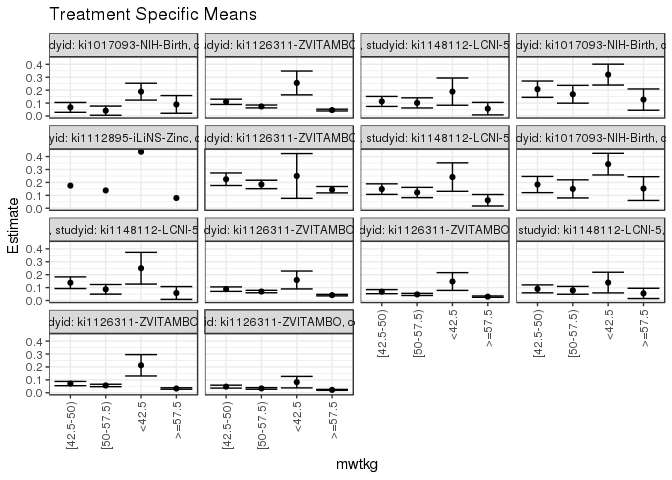

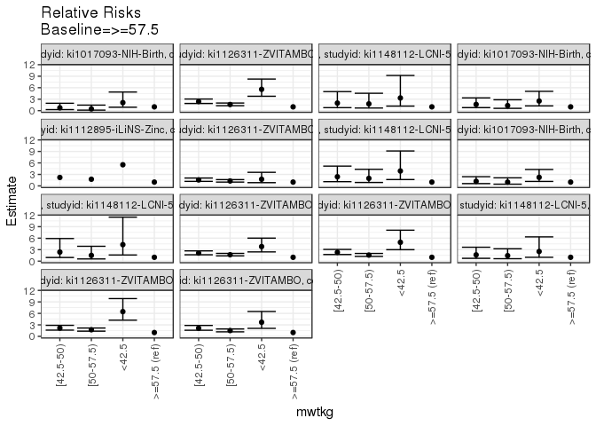

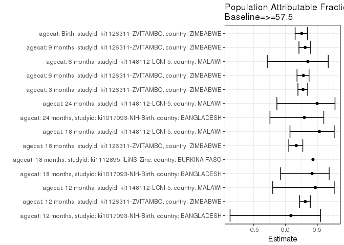

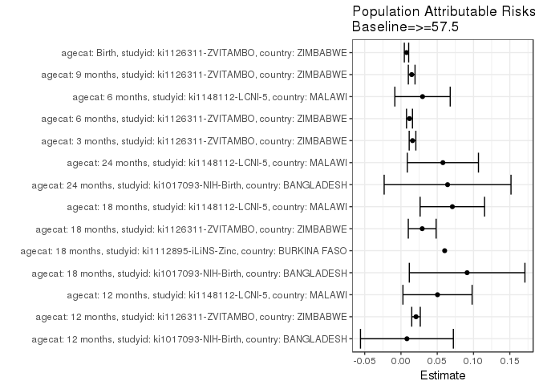

## Results Table

### Parameter: TSM

| agecat | studyid | country | intervention_level | baseline_level | estimate | ci_lower | ci_upper |
| --- | --- | --- | --- | --- | --- | --- | --- |
| Birth | ki1126311-ZVITAMBO | ZIMBABWE | >=57.5 | NA | 0.0223192 | 0.0185684 | 0.0260699 |
| Birth | ki1126311-ZVITAMBO | ZIMBABWE | <42.5 | NA | 0.0821918 | 0.0376383 | 0.1267453 |
| Birth | ki1126311-ZVITAMBO | ZIMBABWE | [42.5-50) | NA | 0.0475504 | 0.0363542 | 0.0587467 |
| Birth | ki1126311-ZVITAMBO | ZIMBABWE | [50-57.5) | NA | 0.0337432 | 0.0277583 | 0.0397281 |
| 3 months | ki1126311-ZVITAMBO | ZIMBABWE | >=57.5 | NA | 0.0417373 | 0.0360316 | 0.0474430 |
| 3 months | ki1126311-ZVITAMBO | ZIMBABWE | <42.5 | NA | 0.1588785 | 0.0896088 | 0.2281482 |
| 3 months | ki1126311-ZVITAMBO | ZIMBABWE | [42.5-50) | NA | 0.0880383 | 0.0708576 | 0.1052189 |
| 3 months | ki1126311-ZVITAMBO | ZIMBABWE | [50-57.5) | NA | 0.0695461 | 0.0600068 | 0.0790854 |
| 6 months | ki1126311-ZVITAMBO | ZIMBABWE | >=57.5 | NA | 0.0299332 | 0.0248650 | 0.0350015 |
| 6 months | ki1126311-ZVITAMBO | ZIMBABWE | <42.5 | NA | 0.1470588 | 0.0783234 | 0.2157942 |
| 6 months | ki1126311-ZVITAMBO | ZIMBABWE | [42.5-50) | NA | 0.0686475 | 0.0527833 | 0.0845118 |
| 6 months | ki1126311-ZVITAMBO | ZIMBABWE | [50-57.5) | NA | 0.0472035 | 0.0389245 | 0.0554825 |
| 6 months | ki1148112-LCNI-5 | MALAWI | >=57.5 | NA | 0.0551181 | 0.0154043 | 0.0948319 |
| 6 months | ki1148112-LCNI-5 | MALAWI | <42.5 | NA | 0.1388889 | 0.0589598 | 0.2188180 |
| 6 months | ki1148112-LCNI-5 | MALAWI | [42.5-50) | NA | 0.0900901 | 0.0593204 | 0.1208598 |
| 6 months | ki1148112-LCNI-5 | MALAWI | [50-57.5) | NA | 0.0786885 | 0.0484531 | 0.1089240 |
| 9 months | ki1126311-ZVITAMBO | ZIMBABWE | >=57.5 | NA | 0.0329477 | 0.0273990 | 0.0384964 |
| 9 months | ki1126311-ZVITAMBO | ZIMBABWE | <42.5 | NA | 0.2127660 | 0.1300257 | 0.2955062 |
| 9 months | ki1126311-ZVITAMBO | ZIMBABWE | [42.5-50) | NA | 0.0713525 | 0.0548870 | 0.0878180 |
| 9 months | ki1126311-ZVITAMBO | ZIMBABWE | [50-57.5) | NA | 0.0566440 | 0.0472933 | 0.0659946 |
| 12 months | ki1017093-NIH-Birth | BANGLADESH | >=57.5 | NA | 0.0895522 | 0.0211108 | 0.1579937 |
| 12 months | ki1017093-NIH-Birth | BANGLADESH | <42.5 | NA | 0.1884058 | 0.1230976 | 0.2537140 |
| 12 months | ki1017093-NIH-Birth | BANGLADESH | [42.5-50) | NA | 0.0666667 | 0.0285670 | 0.1047664 |
| 12 months | ki1017093-NIH-Birth | BANGLADESH | [50-57.5) | NA | 0.0413223 | 0.0058224 | 0.0768222 |
| 12 months | ki1126311-ZVITAMBO | ZIMBABWE | >=57.5 | NA | 0.0458959 | 0.0388604 | 0.0529313 |
| 12 months | ki1126311-ZVITAMBO | ZIMBABWE | <42.5 | NA | 0.2558140 | 0.1635918 | 0.3480361 |
| 12 months | ki1126311-ZVITAMBO | ZIMBABWE | [42.5-50) | NA | 0.1098779 | 0.0894559 | 0.1302999 |
| 12 months | ki1126311-ZVITAMBO | ZIMBABWE | [50-57.5) | NA | 0.0737782 | 0.0626707 | 0.0848857 |
| 12 months | ki1148112-LCNI-5 | MALAWI | >=57.5 | NA | 0.0568182 | 0.0084126 | 0.1052238 |
| 12 months | ki1148112-LCNI-5 | MALAWI | <42.5 | NA | 0.1886792 | 0.0832609 | 0.2940976 |
| 12 months | ki1148112-LCNI-5 | MALAWI | [42.5-50) | NA | 0.1128405 | 0.0741270 | 0.1515540 |
| 12 months | ki1148112-LCNI-5 | MALAWI | [50-57.5) | NA | 0.1013216 | 0.0620357 | 0.1406074 |
| 18 months | ki1017093-NIH-Birth | BANGLADESH | >=57.5 | NA | 0.1269841 | 0.0446778 | 0.2092904 |
| 18 months | ki1017093-NIH-Birth | BANGLADESH | <42.5 | NA | 0.3203125 | 0.2393928 | 0.4012322 |
| 18 months | ki1017093-NIH-Birth | BANGLADESH | [42.5-50) | NA | 0.2075472 | 0.1444421 | 0.2706522 |
| 18 months | ki1017093-NIH-Birth | BANGLADESH | [50-57.5) | NA | 0.1681416 | 0.0991111 | 0.2371720 |
| 18 months | ki1112895-iLiNS-Zinc | BURKINA FASO | >=57.5 | NA | 0.0792683 | NA | NA |
| 18 months | ki1112895-iLiNS-Zinc | BURKINA FASO | <42.5 | NA | 0.4375000 | NA | NA |
| 18 months | ki1112895-iLiNS-Zinc | BURKINA FASO | [42.5-50) | NA | 0.1753247 | NA | NA |
| 18 months | ki1112895-iLiNS-Zinc | BURKINA FASO | [50-57.5) | NA | 0.1379310 | NA | NA |
| 18 months | ki1126311-ZVITAMBO | ZIMBABWE | >=57.5 | NA | 0.1437824 | 0.1190242 | 0.1685406 |
| 18 months | ki1126311-ZVITAMBO | ZIMBABWE | <42.5 | NA | 0.2500000 | 0.0767085 | 0.4232915 |
| 18 months | ki1126311-ZVITAMBO | ZIMBABWE | [42.5-50) | NA | 0.2245614 | 0.1760994 | 0.2730234 |
| 18 months | ki1126311-ZVITAMBO | ZIMBABWE | [50-57.5) | NA | 0.1843575 | 0.1515499 | 0.2171652 |
| 18 months | ki1148112-LCNI-5 | MALAWI | >=57.5 | NA | 0.0619469 | 0.0174702 | 0.1064236 |
| 18 months | ki1148112-LCNI-5 | MALAWI | <42.5 | NA | 0.2413793 | 0.1311754 | 0.3515832 |
| 18 months | ki1148112-LCNI-5 | MALAWI | [42.5-50) | NA | 0.1482759 | 0.1073466 | 0.1892052 |
| 18 months | ki1148112-LCNI-5 | MALAWI | [50-57.5) | NA | 0.1221374 | 0.0824607 | 0.1618141 |
| 24 months | ki1017093-NIH-Birth | BANGLADESH | >=57.5 | NA | 0.1525424 | 0.0606915 | 0.2443932 |
| 24 months | ki1017093-NIH-Birth | BANGLADESH | <42.5 | NA | 0.3414634 | 0.2575630 | 0.4253639 |
| 24 months | ki1017093-NIH-Birth | BANGLADESH | [42.5-50) | NA | 0.1836735 | 0.1210047 | 0.2463423 |
| 24 months | ki1017093-NIH-Birth | BANGLADESH | [50-57.5) | NA | 0.1500000 | 0.0799336 | 0.2200664 |
| 24 months | ki1148112-LCNI-5 | MALAWI | >=57.5 | NA | 0.0581395 | 0.0086397 | 0.1076394 |
| 24 months | ki1148112-LCNI-5 | MALAWI | <42.5 | NA | 0.2500000 | 0.1273961 | 0.3726039 |
| 24 months | ki1148112-LCNI-5 | MALAWI | [42.5-50) | NA | 0.1377778 | 0.0927032 | 0.1828524 |
| 24 months | ki1148112-LCNI-5 | MALAWI | [50-57.5) | NA | 0.0867580 | 0.0494459 | 0.1240701 |

### Parameter: E(Y)

| agecat | studyid | country | intervention_level | baseline_level | estimate | ci_lower | ci_upper |
| --- | --- | --- | --- | --- | --- | --- | --- |
| Birth | ki1126311-ZVITAMBO | ZIMBABWE | NA | NA | 0.0299363 | 0.0267501 | 0.0331225 |
| 3 months | ki1126311-ZVITAMBO | ZIMBABWE | NA | NA | 0.0576476 | 0.0527224 | 0.0625728 |
| 6 months | ki1126311-ZVITAMBO | ZIMBABWE | NA | NA | 0.0416772 | 0.0372816 | 0.0460727 |
| 6 months | ki1148112-LCNI-5 | MALAWI | NA | NA | 0.0848268 | 0.0659398 | 0.1037138 |
| 9 months | ki1126311-ZVITAMBO | ZIMBABWE | NA | NA | 0.0477097 | 0.0428387 | 0.0525806 |
| 12 months | ki1017093-NIH-Birth | BANGLADESH | NA | NA | 0.0977597 | 0.0714636 | 0.1240558 |
| 12 months | ki1126311-ZVITAMBO | ZIMBABWE | NA | NA | 0.0666257 | 0.0605694 | 0.0726820 |
| 12 months | ki1148112-LCNI-5 | MALAWI | NA | NA | 0.1072000 | 0.0829266 | 0.1314734 |
| 18 months | ki1017093-NIH-Birth | BANGLADESH | NA | NA | 0.2181425 | 0.1804842 | 0.2558009 |
| 18 months | ki1112895-iLiNS-Zinc | BURKINA FASO | NA | NA | 0.1394958 | NA | NA |
| 18 months | ki1126311-ZVITAMBO | ZIMBABWE | NA | NA | 0.1730532 | 0.1546148 | 0.1914915 |
| 18 months | ki1148112-LCNI-5 | MALAWI | NA | NA | 0.1327801 | 0.1080281 | 0.1575321 |
| 24 months | ki1017093-NIH-Birth | BANGLADESH | NA | NA | 0.2167832 | 0.1777459 | 0.2558205 |
| 24 months | ki1148112-LCNI-5 | MALAWI | NA | NA | 0.1159170 | 0.0897965 | 0.1420374 |

### Parameter: RR

| agecat | studyid | country | intervention_level | baseline_level | estimate | ci_lower | ci_upper |
| --- | --- | --- | --- | --- | --- | --- | --- |
| Birth | ki1126311-ZVITAMBO | ZIMBABWE | >=57.5 | >=57.5 | 1.0000000 | 1.0000000 | 1.000000 |
| Birth | ki1126311-ZVITAMBO | ZIMBABWE | <42.5 | >=57.5 | 3.6825626 | 2.0877557 | 6.495620 |
| Birth | ki1126311-ZVITAMBO | ZIMBABWE | [42.5-50) | >=57.5 | 2.1304739 | 1.5953056 | 2.845172 |
| Birth | ki1126311-ZVITAMBO | ZIMBABWE | [50-57.5) | >=57.5 | 1.5118480 | 1.1841160 | 1.930287 |
| 3 months | ki1126311-ZVITAMBO | ZIMBABWE | >=57.5 | >=57.5 | 1.0000000 | 1.0000000 | 1.000000 |
| 3 months | ki1126311-ZVITAMBO | ZIMBABWE | <42.5 | >=57.5 | 3.8066319 | 2.4104747 | 6.011449 |
| 3 months | ki1126311-ZVITAMBO | ZIMBABWE | [42.5-50) | >=57.5 | 2.1093433 | 1.6621452 | 2.676860 |
| 3 months | ki1126311-ZVITAMBO | ZIMBABWE | [50-57.5) | >=57.5 | 1.6662825 | 1.3729199 | 2.022330 |
| 6 months | ki1126311-ZVITAMBO | ZIMBABWE | >=57.5 | >=57.5 | 1.0000000 | 1.0000000 | 1.000000 |
| 6 months | ki1126311-ZVITAMBO | ZIMBABWE | <42.5 | >=57.5 | 4.9128959 | 2.9884046 | 8.076733 |
| 6 months | ki1126311-ZVITAMBO | ZIMBABWE | [42.5-50) | >=57.5 | 2.2933559 | 1.7220738 | 3.054156 |
| 6 months | ki1126311-ZVITAMBO | ZIMBABWE | [50-57.5) | >=57.5 | 1.5769597 | 1.2357969 | 2.012306 |
| 6 months | ki1148112-LCNI-5 | MALAWI | >=57.5 | >=57.5 | 1.0000000 | 1.0000000 | 1.000000 |
| 6 months | ki1148112-LCNI-5 | MALAWI | <42.5 | >=57.5 | 2.5198413 | 1.0020590 | 6.336553 |
| 6 months | ki1148112-LCNI-5 | MALAWI | [42.5-50) | >=57.5 | 1.6344916 | 0.7363560 | 3.628086 |
| 6 months | ki1148112-LCNI-5 | MALAWI | [50-57.5) | >=57.5 | 1.4276347 | 0.6309328 | 3.230361 |
| 9 months | ki1126311-ZVITAMBO | ZIMBABWE | >=57.5 | >=57.5 | 1.0000000 | 1.0000000 | 1.000000 |
| 9 months | ki1126311-ZVITAMBO | ZIMBABWE | <42.5 | >=57.5 | 6.4576904 | 4.2270005 | 9.865569 |
| 9 months | ki1126311-ZVITAMBO | ZIMBABWE | [42.5-50) | >=57.5 | 2.1656302 | 1.6274772 | 2.881733 |
| 9 months | ki1126311-ZVITAMBO | ZIMBABWE | [50-57.5) | >=57.5 | 1.7192088 | 1.3580379 | 2.176433 |
| 12 months | ki1017093-NIH-Birth | BANGLADESH | >=57.5 | >=57.5 | 1.0000000 | 1.0000000 | 1.000000 |
| 12 months | ki1017093-NIH-Birth | BANGLADESH | <42.5 | >=57.5 | 2.1038647 | 0.9089889 | 4.869418 |
| 12 months | ki1017093-NIH-Birth | BANGLADESH | [42.5-50) | >=57.5 | 0.7444444 | 0.2866694 | 1.933229 |
| 12 months | ki1017093-NIH-Birth | BANGLADESH | [50-57.5) | >=57.5 | 0.4614326 | 0.1461291 | 1.457068 |
| 12 months | ki1126311-ZVITAMBO | ZIMBABWE | >=57.5 | >=57.5 | 1.0000000 | 1.0000000 | 1.000000 |
| 12 months | ki1126311-ZVITAMBO | ZIMBABWE | <42.5 | >=57.5 | 5.5737924 | 3.7672064 | 8.246737 |
| 12 months | ki1126311-ZVITAMBO | ZIMBABWE | [42.5-50) | >=57.5 | 2.3940706 | 1.8815105 | 3.046262 |
| 12 months | ki1126311-ZVITAMBO | ZIMBABWE | [50-57.5) | >=57.5 | 1.6075133 | 1.2967091 | 1.992813 |
| 12 months | ki1148112-LCNI-5 | MALAWI | >=57.5 | >=57.5 | 1.0000000 | 1.0000000 | 1.000000 |
| 12 months | ki1148112-LCNI-5 | MALAWI | <42.5 | >=57.5 | 3.3207547 | 1.1988783 | 9.198108 |
| 12 months | ki1148112-LCNI-5 | MALAWI | [42.5-50) | >=57.5 | 1.9859922 | 0.7927029 | 4.975591 |
| 12 months | ki1148112-LCNI-5 | MALAWI | [50-57.5) | >=57.5 | 1.7832599 | 0.6993673 | 4.546990 |
| 18 months | ki1017093-NIH-Birth | BANGLADESH | >=57.5 | >=57.5 | 1.0000000 | 1.0000000 | 1.000000 |
| 18 months | ki1017093-NIH-Birth | BANGLADESH | <42.5 | >=57.5 | 2.5224609 | 1.2580725 | 5.057585 |
| 18 months | ki1017093-NIH-Birth | BANGLADESH | [42.5-50) | >=57.5 | 1.6344340 | 0.7988057 | 3.344210 |
| 18 months | ki1017093-NIH-Birth | BANGLADESH | [50-57.5) | >=57.5 | 1.3241150 | 0.6147739 | 2.851911 |
| 18 months | ki1112895-iLiNS-Zinc | BURKINA FASO | >=57.5 | >=57.5 | 1.0000000 | NA | NA |
| 18 months | ki1112895-iLiNS-Zinc | BURKINA FASO | <42.5 | >=57.5 | 5.5192308 | NA | NA |
| 18 months | ki1112895-iLiNS-Zinc | BURKINA FASO | [42.5-50) | >=57.5 | 2.2117882 | NA | NA |
| 18 months | ki1112895-iLiNS-Zinc | BURKINA FASO | [50-57.5) | >=57.5 | 1.7400531 | NA | NA |
| 18 months | ki1126311-ZVITAMBO | ZIMBABWE | >=57.5 | >=57.5 | 1.0000000 | 1.0000000 | 1.000000 |
| 18 months | ki1126311-ZVITAMBO | ZIMBABWE | <42.5 | >=57.5 | 1.7387387 | 0.8512296 | 3.551583 |
| 18 months | ki1126311-ZVITAMBO | ZIMBABWE | [42.5-50) | >=57.5 | 1.5618144 | 1.1850244 | 2.058409 |
| 18 months | ki1126311-ZVITAMBO | ZIMBABWE | [50-57.5) | >=57.5 | 1.2821984 | 1.0009504 | 1.642472 |
| 18 months | ki1148112-LCNI-5 | MALAWI | >=57.5 | >=57.5 | 1.0000000 | 1.0000000 | 1.000000 |
| 18 months | ki1148112-LCNI-5 | MALAWI | <42.5 | >=57.5 | 3.8965517 | 1.6640313 | 9.124297 |
| 18 months | ki1148112-LCNI-5 | MALAWI | [42.5-50) | >=57.5 | 2.3935961 | 1.1091358 | 5.165555 |
| 18 months | ki1148112-LCNI-5 | MALAWI | [50-57.5) | >=57.5 | 1.9716467 | 0.8965657 | 4.335868 |
| 24 months | ki1017093-NIH-Birth | BANGLADESH | >=57.5 | >=57.5 | 1.0000000 | 1.0000000 | 1.000000 |
| 24 months | ki1017093-NIH-Birth | BANGLADESH | <42.5 | >=57.5 | 2.2384824 | 1.1681975 | 4.289346 |
| 24 months | ki1017093-NIH-Birth | BANGLADESH | [42.5-50) | >=57.5 | 1.2040816 | 0.6026815 | 2.405603 |
| 24 months | ki1017093-NIH-Birth | BANGLADESH | [50-57.5) | >=57.5 | 0.9833333 | 0.4589195 | 2.107002 |
| 24 months | ki1148112-LCNI-5 | MALAWI | >=57.5 | >=57.5 | 1.0000000 | 1.0000000 | 1.000000 |
| 24 months | ki1148112-LCNI-5 | MALAWI | <42.5 | >=57.5 | 4.3000000 | 1.6097436 | 11.486301 |
| 24 months | ki1148112-LCNI-5 | MALAWI | [42.5-50) | >=57.5 | 2.3697778 | 0.9519016 | 5.899609 |
| 24 months | ki1148112-LCNI-5 | MALAWI | [50-57.5) | >=57.5 | 1.4922374 | 0.5748891 | 3.873395 |

### Parameter: PAR

| agecat | studyid | country | intervention_level | baseline_level | estimate | ci_lower | ci_upper |
| --- | --- | --- | --- | --- | --- | --- | --- |
| Birth | ki1126311-ZVITAMBO | ZIMBABWE | >=57.5 | NA | 0.0076171 | 0.0046232 | 0.0106111 |
| 3 months | ki1126311-ZVITAMBO | ZIMBABWE | >=57.5 | NA | 0.0159103 | 0.0113175 | 0.0205031 |
| 6 months | ki1126311-ZVITAMBO | ZIMBABWE | >=57.5 | NA | 0.0117439 | 0.0076312 | 0.0158567 |
| 6 months | ki1148112-LCNI-5 | MALAWI | >=57.5 | NA | 0.0297087 | -0.0084396 | 0.0678569 |
| 9 months | ki1126311-ZVITAMBO | ZIMBABWE | >=57.5 | NA | 0.0147620 | 0.0101537 | 0.0193703 |
| 12 months | ki1017093-NIH-Birth | BANGLADESH | >=57.5 | NA | 0.0082074 | -0.0558030 | 0.0722178 |
| 12 months | ki1126311-ZVITAMBO | ZIMBABWE | >=57.5 | NA | 0.0207299 | 0.0148545 | 0.0266053 |
| 12 months | ki1148112-LCNI-5 | MALAWI | >=57.5 | NA | 0.0503818 | 0.0027112 | 0.0980524 |
| 18 months | ki1017093-NIH-Birth | BANGLADESH | >=57.5 | NA | 0.0911584 | 0.0114783 | 0.1708386 |
| 18 months | ki1112895-iLiNS-Zinc | BURKINA FASO | >=57.5 | NA | 0.0602275 | NA | NA |
| 18 months | ki1126311-ZVITAMBO | ZIMBABWE | >=57.5 | NA | 0.0292708 | 0.0100873 | 0.0484543 |
| 18 months | ki1148112-LCNI-5 | MALAWI | >=57.5 | NA | 0.0708332 | 0.0264205 | 0.1152459 |
| 24 months | ki1017093-NIH-Birth | BANGLADESH | >=57.5 | NA | 0.0642408 | -0.0231659 | 0.1516476 |
| 24 months | ki1148112-LCNI-5 | MALAWI | >=57.5 | NA | 0.0577774 | 0.0087532 | 0.1068017 |

### Parameter: PAF

| agecat | studyid | country | intervention_level | baseline_level | estimate | ci_lower | ci_upper |
| --- | --- | --- | --- | --- | --- | --- | --- |
| Birth | ki1126311-ZVITAMBO | ZIMBABWE | >=57.5 | NA | 0.2544444 | 0.1514784 | 0.3449157 |
| 3 months | ki1126311-ZVITAMBO | ZIMBABWE | >=57.5 | NA | 0.2759927 | 0.1953890 | 0.3485217 |
| 6 months | ki1126311-ZVITAMBO | ZIMBABWE | >=57.5 | NA | 0.2817834 | 0.1809073 | 0.3702361 |
| 6 months | ki1148112-LCNI-5 | MALAWI | >=57.5 | NA | 0.3502273 | -0.2863029 | 0.6717690 |
| 9 months | ki1126311-ZVITAMBO | ZIMBABWE | >=57.5 | NA | 0.3094127 | 0.2113962 | 0.3952467 |
| 12 months | ki1017093-NIH-Birth | BANGLADESH | >=57.5 | NA | 0.0839552 | -0.8715216 | 0.5516279 |
| 12 months | ki1126311-ZVITAMBO | ZIMBABWE | >=57.5 | NA | 0.3111392 | 0.2218068 | 0.3902168 |
| 12 months | ki1148112-LCNI-5 | MALAWI | >=57.5 | NA | 0.4699796 | -0.2007267 | 0.7660404 |
| 18 months | ki1017093-NIH-Birth | BANGLADESH | >=57.5 | NA | 0.4178846 | -0.0812055 | 0.6865922 |
| 18 months | ki1112895-iLiNS-Zinc | BURKINA FASO | >=57.5 | NA | 0.4317514 | NA | NA |
| 18 months | ki1126311-ZVITAMBO | ZIMBABWE | >=57.5 | NA | 0.1691432 | 0.0516509 | 0.2720793 |
| 18 months | ki1148112-LCNI-5 | MALAWI | >=57.5 | NA | 0.5334624 | 0.0705505 | 0.7658212 |
| 24 months | ki1017093-NIH-Birth | BANGLADESH | >=57.5 | NA | 0.2963368 | -0.2441748 | 0.6020319 |
| 24 months | ki1148112-LCNI-5 | MALAWI | >=57.5 | NA | 0.4984380 | -0.1353677 | 0.7784291 |